# Задачи по Эконометрике-2: LPM-модель

Н.В. Артамонов (МГИМО МИД России)

# 1 Подгонка модели

## 1.1 approve equation #1

Для датасета `loanapp` рассмотрим регрессию **approve на mortno, unem, dep, male, married, yjob, self**

Спецификация:
$$approve=\beta_0+\beta_1mortno+\beta_2unem+\beta_3dep+\beta_4male+\beta_5married+\beta_6yjob+\beta_7self+u$$

Альтернативная спецификация:
$$P(approve=1)=\beta_0+\beta_1mortno+\beta_2unem+\beta_3dep+\beta_4male+\beta_5married+\beta_6yjob+\beta_7self$$

Оцените модель на данных и укажите коэффициенты подогнанной модели. **Ответ округлите до 3-х десятичных знаков.**

Ответ:

```
(Intercept)      mortno        unem         dep        male     married
      0.864       0.073      -0.006      -0.018       0.002       0.046
       yjob        self
     -0.001      -0.036
```

Дайте интерпретацию коэффициентам модели.

## 1.2 approve equation #2

Для датасета `loanapp` рассморим регрессию **approve на appinc, appinc^2, mortno, unem, dep, male, married, yjob, self**

Оцените модель на данных и укажите коэффициенты подогнанной модели. **Ответ округлите до 3-х десятичных знаков.**

Ответ:

```
(Intercept)      appinc I(appinc^2)      mortno        unem         dep
      0.842       0.001       0.000       0.066      -0.006      -0.017
       male     married        yjob        self
     -0.003       0.043      -0.001      -0.040
```

Дайте интерпретацию коэффициентам модели.

## 1.3 labour force equation #1

Для датасета `TableF5-1` рассмотрим регрессию **LFP на WA, WA^2, WE, KL6, K618, CIT, UN, log(FAMINC)**

Спецификация:
$$LFP=\beta_0+\beta_1WA+\beta_2WA^2+\beta_3WE+\beta_4KL6+\beta_5K618+\beta_5CIT+\beta_7UN+\beta_8\log(FAMINC)+u$$

Альтернативная спецификация:
$$P(LFP=1)=\beta_0+\beta_1WA+\beta_2WA^2+\beta_3WE+\beta_4KL6+\beta_5K618+\beta_5CIT+\beta_7UN+\beta_8\log(FAMINC)$$

Оцените модель на данных и укажите коэффициенты подогнанной модели. **Ответ округлите до 3-х десятичных знаков.**

Ответ:

```
(Intercept)          WA     I(WA^2)          WE         KL6        K618
     -0.321       0.008       0.000       0.038      -0.296      -0.021
        CIT          UN log(FAMINC)
     -0.048      -0.004       0.072
```

Дайте интерпретацию коэффициентам модели.

## 1.4 labour force equation #2

Для датасета `TableF5-1` рассмотрим регрессию **LFP на WA, WE, CIT, UN, log(FAMINC)**

Оцените модель на данных и укажите коэффициенты подогнанной модели. **Ответ округлите до 3-х десятичных знаков.**

Ответ:

```
(Intercept)          WA          WE         CIT          UN log(FAMINC)
     -0.536      -0.004       0.033      -0.048      -0.005       0.094
```

Дайте интерпретацию коэффициентам модели.

## 1.5 Замечание: почему log(FAMINC)

Нарисуем гистограмму FAMINC с наложенной кривой нормального распределения

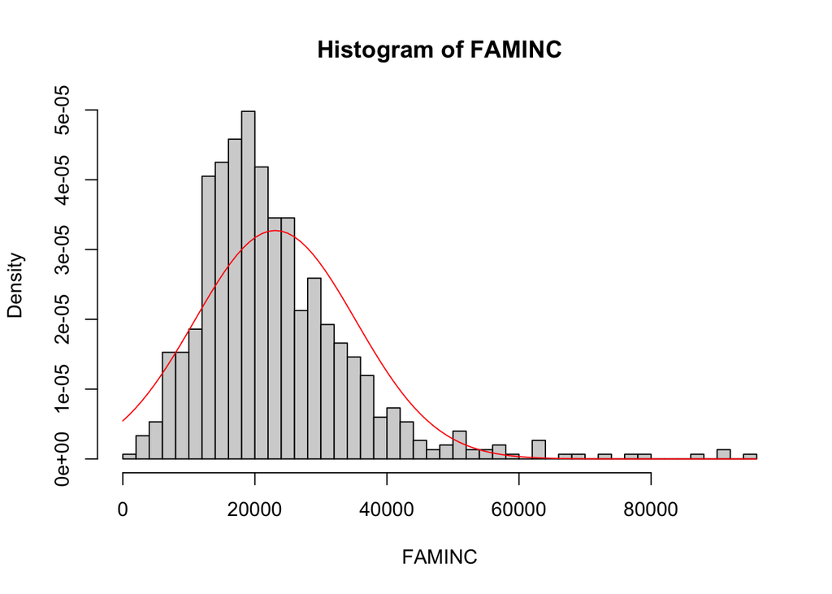

Нарисуем гистограмму log(FAMINC) с наложенной кривой нормального распределения

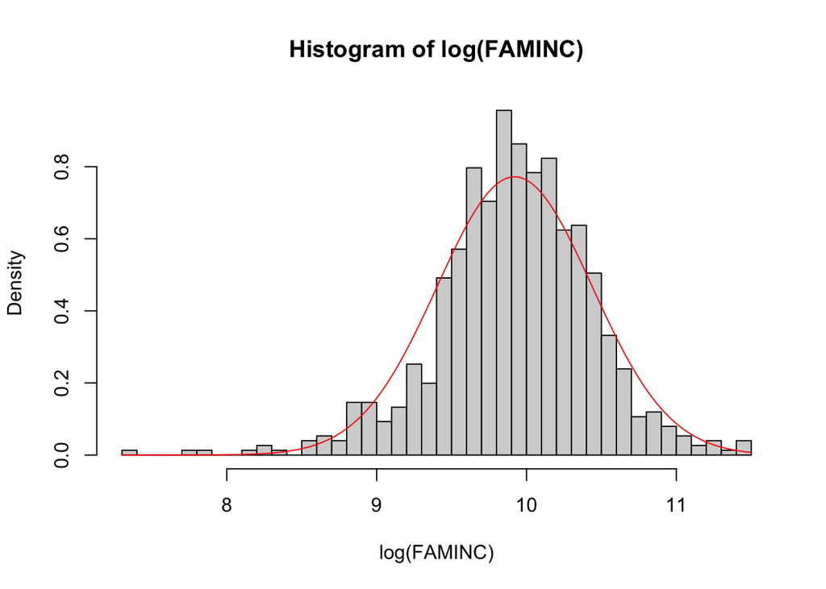

# 2 t-тест

## 2.1 approve equation #1

Для датасета `loanapp` рассмотрим регрессию **approve на mortno, unem, dep, male, married, yjob, self**

Подгоните модель и вычислите (робастные) t-статистика для каждого коэффициента. **Ответ округлите до 3-х десятичных знаков.**

Ответ

```
(Intercept)      mortno        unem         dep        male     married
     37.135       4.886      -1.605      -2.429       0.089       2.458
       yjob        self
     -0.107      -1.464
```

Модель была подогнана по 1971 наблюдениям. Уровень значимости 1%

Вычислите критическое значения для t-теста. **Ответ округлите до 3-х десятичных знаков.**

```
[1] 2.578
```

Укажите результаты робастного и неробастного t-тест:

Результаты t-теста для коэффициентов (неробастные s.e.)

```
t test of coefficients:

               Estimate  Std. Error t value  Pr(>|t|)
(Intercept)  0.86421157  0.02190972 39.4442 < 2.2e-16 ***
mortno       0.07325103  0.01599964  4.5783 4.982e-06 ***
unem        -0.00643412  0.00346299 -1.8580  0.063323 .
dep         -0.01847231  0.00718712 -2.5702  0.010237 *
male         0.00190705  0.02031399  0.0939  0.925215
married      0.04594613  0.01764424  2.6040  0.009283 **
yjob        -0.00066249  0.00668556 -0.0991  0.921075
self        -0.03611981  0.02228924 -1.6205  0.105285
---
Signif. codes:  0 '***' 0.001 '**' 0.01 '*' 0.05 '.' 0.1 ' ' 1
```

Результаты t-теста для коэффициентов (робастные s.e.)

```
t test of coefficients:

               Estimate  Std. Error t value  Pr(>|t|)
(Intercept)  0.86421157  0.02327228 37.1348 < 2.2e-16 ***
mortno       0.07325103  0.01499345  4.8855 1.115e-06 ***
unem        -0.00643412  0.00400817 -1.6053   0.10860
dep         -0.01847231  0.00760465 -2.4291   0.01523 *
male         0.00190705  0.02135089  0.0893   0.92884
married      0.04594613  0.01869174  2.4581   0.01405 *
yjob        -0.00066249  0.00618859 -0.1070   0.91476
self        -0.03611981  0.02467054 -1.4641   0.14333
---
Signif. codes:  0 '***' 0.001 '**' 0.01 '*' 0.05 '.' 0.1 ' ' 1
```

Какие коэффициенты значимы? Ответ

```
[1] "(Intercept)" "mortno"
```

## 2.2 approve equation #2

Для датасета `loanapp` рассмотрим регрессию **approve на appinc, appinc^2, mortno, unem, dep, male, married, yjob, self**

Подгоните модель и вычислите (робастные) t-статистика для каждого коэффициента. **Ответ округлите до 3-х десятичных знаков.**

Ответ

```
(Intercept)      appinc I(appinc^2)      mortno        unem         dep
     31.003       1.958      -2.374       4.321      -1.515      -2.280
       male     married        yjob        self
     -0.135       2.309      -0.140      -1.602
```

Модель была подогнана по 1971 наблюдениям. Уровень значимости 1%

Вычислите критическое значения для t-теста. **Ответ округлите до 3-х десятичных знаков.**

```
[1] 2.578
```

Укажите результаты робастного и неробастного t-тест:

Результаты t-теста для коэффициентов (неробастные s.e.)

```
t test of coefficients:

               Estimate  Std. Error t value  Pr(>|t|)
(Intercept)  8.4200e-01  2.5285e-02 33.2996 < 2.2e-16 ***
appinc       5.1271e-04  2.4628e-04  2.0818  0.037488 *
I(appinc^2) -1.0072e-06  3.5927e-07 -2.8034  0.005107 **
mortno       6.6040e-02  1.6390e-02  4.0293 5.807e-05 ***
unem        -6.1034e-03  3.4737e-03 -1.7570  0.079066 .
dep         -1.7071e-02  7.1896e-03 -2.3744  0.017675 *
male        -2.8900e-03  2.0406e-02 -0.1416  0.887389
married      4.3276e-02  1.7669e-02  2.4493  0.014401 *
yjob        -8.7741e-04  6.6719e-03 -0.1315  0.895387
self        -4.0432e-02  2.2638e-02 -1.7860  0.074249 .
---
Signif. codes:  0 '***' 0.001 '**' 0.01 '*' 0.05 '.' 0.1 ' ' 1
```

Результаты t-теста для коэффициентов (робастные s.e.)

```
t test of coefficients:

               Estimate  Std. Error t value  Pr(>|t|)
(Intercept)  8.4200e-01  2.7158e-02 31.0034 < 2.2e-16 ***
appinc       5.1271e-04  2.6182e-04  1.9583   0.05034 .
I(appinc^2) -1.0072e-06  4.2423e-07 -2.3741   0.01769 *
mortno       6.6040e-02  1.5282e-02  4.3214 1.628e-05 ***
unem        -6.1034e-03  4.0291e-03 -1.5149   0.12997
dep         -1.7071e-02  7.4865e-03 -2.2802   0.02270 *
male        -2.8900e-03  2.1405e-02 -0.1350   0.89261
married      4.3276e-02  1.8743e-02  2.3089   0.02105 *
yjob        -8.7741e-04  6.2623e-03 -0.1401   0.88859
self        -4.0432e-02  2.5244e-02 -1.6016   0.10940
---
Signif. codes:  0 '***' 0.001 '**' 0.01 '*' 0.05 '.' 0.1 ' ' 1
```

Какие коэффициенты значимы? Ответ

```
[1] "(Intercept)" "mortno"
```

## 2.3 labour force equation #1

Для датасета `TableF5-1` рассмотрим регрессию **LFP на WA, WA^2, WE, KL6, K618, CIT, UN, log(FAMINC)**

Подгоните модель и вычислите (робастные) t-статистика для каждого коэффициента. **Ответ округлите до 3-х десятичных знаков.**

Ответ

```
(Intercept)          WA     I(WA^2)          WE         KL6        K618
     -0.549       0.307      -0.843       4.736      -8.763      -1.409
        CIT          UN log(FAMINC)
     -1.300      -0.633       1.921
```

Модель была подогнана по 753 наблюдениям. Уровень значимости 1%

Вычислите критическое значения для t-теста. **Ответ округлите до 3-х десятичных знаков.**

```
[1] 2.582
```

Укажите результаты робастного и неробастного t-тест:

Результаты t-теста для коэффициентов (неробастные s.e.)

```
t test of coefficients:

               Estimate  Std. Error t value  Pr(>|t|)
(Intercept) -0.32112148  0.59193164 -0.5425   0.58764
WA           0.00751037  0.02458551  0.3055   0.76009
I(WA^2)     -0.00023998  0.00028348 -0.8465   0.39752
WE           0.03765641  0.00823220  4.5743 5.597e-06 ***
KL6         -0.29591484  0.03693876 -8.0110 4.391e-15 ***
K618        -0.02092428  0.01458904 -1.4342   0.15192
CIT         -0.04820408  0.03757742 -1.2828   0.19996
UN          -0.00360208  0.00556405 -0.6474   0.51758
log(FAMINC)  0.07236590  0.03682861  1.9649   0.04979 *
---
Signif. codes:  0 '***' 0.001 '**' 0.01 '*' 0.05 '.' 0.1 ' ' 1
```

Результаты t-теста для коэффициентов (робастные s.e.)

```
t test of coefficients:

               Estimate  Std. Error t value  Pr(>|t|)
(Intercept) -0.32112148  0.58458980 -0.5493   0.58296
WA           0.00751037  0.02444013  0.3073   0.75870
I(WA^2)     -0.00023998  0.00028469 -0.8430   0.39952
WE           0.03765641  0.00795071  4.7362 2.608e-06 ***
KL6         -0.29591484  0.03376701 -8.7634 < 2.2e-16 ***
K618        -0.02092428  0.01484965 -1.4091   0.15923
CIT         -0.04820408  0.03706993 -1.3004   0.19388
UN          -0.00360208  0.00569123 -0.6329   0.52698
log(FAMINC)  0.07236590  0.03767997  1.9205   0.05517 .
---
Signif. codes:  0 '***' 0.001 '**' 0.01 '*' 0.05 '.' 0.1 ' ' 1
```

Какие коэффициенты значимы? Ответ

```
[1] "WE"  "KL6"
```

## 2.4 labour force equation #2

Для датасета `TableF5-1` рассмотрим регрессию **LFP на WA, WE, CIT, UN, log(FAMINC)**

Подгоните модель и вычислите (робастные) t-статистика для каждого коэффициента. **Ответ округлите до 3-х десятичных знаков.**

Ответ

```
(Intercept)          WA          WE         CIT          UN log(FAMINC)
     -1.457      -1.635       4.036      -1.212      -0.855       2.351
```

Модель была подогнана по 753 наблюдениям. Уровень значимости 5%

Вычислите критическое значения для t-теста. **Ответ округлите до 3-х десятичных знаков.**

```
[1] 1.963
```

Укажите результаты робастного и неробастного t-тест:

Результаты t-теста для коэффициентов (неробастные s.e.)

```
t test of coefficients:

              Estimate Std. Error t value  Pr(>|t|)
(Intercept) -0.5358992  0.3602416 -1.4876   0.13728
WA          -0.0037303  0.0022368 -1.6677   0.09579 .
WE           0.0332937  0.0085063  3.9140 9.908e-05 ***
CIT         -0.0477581  0.0392322 -1.2173   0.22387
UN          -0.0050316  0.0057988 -0.8677   0.38585
log(FAMINC)  0.0935407  0.0382020  2.4486   0.01457 *
---
Signif. codes:  0 '***' 0.001 '**' 0.01 '*' 0.05 '.' 0.1 ' ' 1
```

Результаты t-теста для коэффициентов (робастные s.e.)

```
t test of coefficients:

              Estimate Std. Error t value  Pr(>|t|)
(Intercept) -0.5358992  0.3679039 -1.4566   0.14564
WA          -0.0037303  0.0022813 -1.6352   0.10243
WE           0.0332937  0.0082483  4.0364 5.987e-05 ***
CIT         -0.0477581  0.0394136 -1.2117   0.22600
UN          -0.0050316  0.0058823 -0.8554   0.39262
log(FAMINC)  0.0935407  0.0397955  2.3505   0.01901 *
---
Signif. codes:  0 '***' 0.001 '**' 0.01 '*' 0.05 '.' 0.1 ' ' 1
```

Какие коэффициенты значимы? Ответ

```
[1] "WE"          "log(FAMINC)"
```

# 3 F-тест: значимость регрессии

## 3.1 approve equation #1

Для датасета `loanapp` рассмотрим регрессию **approve на unem, male, yjob, self**

Результаты оценивания

```
===============================================
                       Зависимая переменная
                    ---------------------------
                              approve
-----------------------------------------------
unem                         -0.007**
                              (0.003)

male                           0.021
                              (0.019)

yjob                           0.001
                              (0.007)

self                          -0.030
                              (0.022)

Constant                     0.891***
                              (0.021)

-----------------------------------------------
Observations                   1974
R2                             0.004
Adjusted R2                    0.002
Residual Std. Error            0.329
F Statistic                   2.029*
===============================================
Note:               *p<0.1; **p<0.05; ***p<0.01
```

Тестируется значимость регрессии, т.е. гипотеза $H_0:\beta_{unem}=\beta_{male}=\beta_{yjob}=\beta_{self}=0$. Уровень значимости 10%.

Вычислите критическое значение для гипотезы. **Ответ округлите до 3-х десятичных знаков.**

Ответ:

```
[1] 1.948
```

Получите результаты неробастного F-теста. **Ответ округлите до 3-х десятичных знаков.**

```
=============
F     Pr(> F)
-------------
2.029  0.088
-------------
```

Получите результаты робастного F-теста. **Ответ округлите до 3-х десятичных знаков.**

```
=============
F     Pr(> F)
-------------
1.677  0.153
-------------
```

Какой можно сделать вывод?

```
[1] "Регрессия незначима"
```

## 3.2 approve equation #2

Для датасета `loanapp` рассмотрим регрессию **approve на appinc, appinc^2, mortno, dep**

Результаты оценивания

```
===============================================
                       Зависимая переменная
                    ---------------------------
                              approve
-----------------------------------------------
appinc                       0.00052**
                             (0.00024)

I(appinc2)                 -0.000001***
                            (0.0000004)

mortno                      0.06903***
                             (0.01623)

dep                          -0.01163*
                             (0.00672)

Constant                    0.83416***
                             (0.01707)

-----------------------------------------------
Observations                   1986
R2                            0.01805
Adjusted R2                   0.01607
Residual Std. Error           0.32571
F Statistic                 9.10590***
===============================================
Note:               *p<0.1; **p<0.05; ***p<0.01
```

Тестируется значимость регрессии, т.е. гипотеза $H_0:\beta_{appinc}=\beta_{appinc^2}=\beta_{mortno}=\beta_{dep}=0$. Уровень значимости 5%.

Вычислите критическое значение для гипотезы. **Ответ округлите до 3-х десятичных знаков.**

Ответ:

```
[1] 2.376
```

Получите результаты неробастного F-теста. **Ответ округлите до 3-х десятичных знаков.**

```
=============
F     Pr(> F)
-------------
9.106 0.00000
-------------
```

Получите результаты робастного F-теста. **Ответ округлите до 3-х десятичных знаков.**

```
=============
F     Pr(> F)
-------------
8.188 0.00000
-------------
```

Какой можно сделать вывод?

```
[1] "Регрессия значима"
```

## 3.3 approve equation #3

Для датасета `loanapp` рассмотрим регрессию **approve на dep, male, married**

Результаты оценивания

```
===============================================
                       Зависимая переменная
                    ---------------------------
                              approve
-----------------------------------------------
dep                          -0.016**
                              (0.007)

male                          -0.002
                              (0.020)

married                      0.057***
                              (0.018)

Constant                     0.852***
                              (0.018)

-----------------------------------------------
Observations                   1971
R2                             0.006
Adjusted R2                    0.005
Residual Std. Error            0.329
F Statistic                  4.155***
===============================================
Note:               *p<0.1; **p<0.05; ***p<0.01
```

Тестируется значимость регрессии, т.е. гипотеза $H_0:\beta_{dep}=\beta_{male}=\beta_{married}=0$. Уровень значимости 1%.

Вычислите критическое значение для гипотезы. **Ответ округлите до 3-х десятичных знаков.**

Ответ:

```
[1] 3.792
```

Получите результаты неробастного F-теста. **Ответ округлите до 3-х десятичных знаков.**

```
=============
F     Pr(> F)
-------------
4.155  0.006
-------------
```

Получите результаты робастного F-теста. **Ответ округлите до 3-х десятичных знаков.**

```
=============
F     Pr(> F)
-------------
3.724  0.011
-------------
```

Какой можно сделать вывод?

```
[1] "Регрессия незначима"
```

# 4 F-тест: совместная значимость

## 4.1 approve equation #1

Для датасета `loanapp` рассмотрим регрессию **approve на appinc, appinc^2, mortno, unem, dep, male, married, yjob, self**

Результаты оценивания

```
========================================================
                            Зависимая переменная
                    ------------------------------------
                                  approve
                        (1)         (2)         (3)
--------------------------------------------------------
appinc               0.00051**               0.00060**
                     (0.00025)               (0.00024)

I(appinc2)          -0.000001***            -0.000001***
                    (0.0000004)             (0.0000004)

mortno               0.06604***  0.07325***  0.06649***
                     (0.01639)   (0.01600)   (0.01619)

unem                 -0.00610*   -0.00643*
                     (0.00347)   (0.00346)

dep                  -0.01707**  -0.01847**
                     (0.00719)   (0.00719)

male                  -0.00289    0.00191     0.00292
                     (0.02041)   (0.02031)   (0.01917)

married              0.04328**   0.04595***
                     (0.01767)   (0.01764)

yjob                  -0.00088    -0.00066    0.00020
                     (0.00667)   (0.00669)   (0.00657)

self                 -0.04043*    -0.03612   -0.04999**
                     (0.02264)   (0.02229)   (0.02227)

Constant             0.84200***  0.86421***  0.82411***
                     (0.02529)   (0.02191)   (0.02149)

--------------------------------------------------------
Observations            1971        1971        1974
R2                    0.02538     0.02026     0.01929
Adjusted R2           0.02091     0.01677     0.01630
Residual Std. Error   0.32597     0.32666     0.32652
F Statistic          5.67446***  5.80014***  6.44729***
========================================================
Note:                        *p<0.1; **p<0.05; ***p<0.01
```

### 4.1.1 Гипотеза 1

Тестируйте значимость влияния дохода, т.е. $H_0:\beta_{appinc}=\beta_{appinc^2}=0$. Уровень значимости 5%.

Результаты неробастного F-теста

```
=============
F     Pr(> F)
-------------
5.149  0.006
-------------
```

Результаты робастного F-теста

```
=============
F     Pr(> F)
-------------
2.961  0.052
-------------
```

Вычислите критическое значение для гипотезы. **Ответ округлите до 3-х десятичных знаков.**

Ответ:

```
[1] 3
```

Какой можно сделать вывод?

```
[1] "Гипотеза не отвергается"
```

### 4.1.2 Гипотеза 2

Тестируйте гипотезу $H_0:\beta_{unem}=\beta_{dep}=\beta_{married}=0$. Уровень значимости 1%.

Результаты неробастного F-теста

```
=============
F     Pr(> F)
-------------
4.054  0.007
-------------
```

Результаты робастного F-теста

```
=============
F     Pr(> F)
-------------
3.469  0.016
-------------
```

Вычислите критическое значение для гипотезы. **Ответ округлите до 3-х десятичных знаков.**

Ответ:

```
[1] 3.792
```

Какой можно сделать вывод?

```
[1] "Гипотеза не отвергается"
```

# 5 Прогноз

## 5.1 approve equation

Для датасета `loanapp` рассмотрим регрессию **approve на mortno, unem, dep, married**

Результаты оценивания

```
===============================================
                       Зависимая переменная
                    ---------------------------
                              approve
-----------------------------------------------
mortno                       0.071***
                              (0.016)

unem                         -0.008**
                              (0.003)

dep                          -0.019***
                              (0.007)

married                      0.046***
                              (0.017)

Constant                     0.867***
                              (0.018)

-----------------------------------------------
Observations                   1986
R2                             0.019
Adjusted R2                    0.017
Residual Std. Error            0.326
F Statistic                  9.445***
===============================================
Note:               *p<0.1; **p<0.05; ***p<0.01
```

Рассмотрим трёх людей с характеристиками

```
==========================
  mortno unem  dep married
--------------------------
1   1    3.200  0     1
2   1    3.900  1     0
3   0    1.800  0     1
--------------------------
```

Вычислите прогноз для каждого человека по подогнанной модели.  
**Ответ округлите до 3-х десятичных знаков.**

Ответ:

```
=========
  Прогноз
---------
1  0.959
2  0.890
3  0.899
---------
```

Какая интерпретация прогнозов?

## 5.2 labour force equation

Для датасета `TableF5-1` рассмотрим регрессию **LFP на WA, WA^2, CIT, UN, log(FAMINC)**

Результаты оценивания

```
===============================================
                       Зависимая переменная
                    ---------------------------
                                LFP
-----------------------------------------------
WA                            0.042*
                              (0.024)

I(WA2)                        -0.001*
                             (0.0003)

CIT                           -0.039
                              (0.039)

UN                            -0.004
                              (0.006)

log(FAMINC)                  0.140***
                              (0.036)

Constant                     -1.525**
                              (0.595)

-----------------------------------------------
Observations                    753
R2                             0.033
Adjusted R2                    0.027
Residual Std. Error            0.489
F Statistic                  5.171***
===============================================
Note:               *p<0.1; **p<0.05; ***p<0.01
```

Расстроим трёх людей с характеристиками

```
=====================
  WA CIT  UN   FAMINC
---------------------
1 34  1    3   35000
2 36  0    5   48500
3 42  0  7.500 67800
---------------------
```

Вычислите прогноз для каждого человека по подогнанной модели.  
**Ответ округлите до 3-х десятичных знаков.**

Ответ:

```
=========
  Прогноз
---------
1  0.686
2  0.771
3  0.804
---------
```

Какая интерпретация прогнозов?

# 6 Вопросы адекватности

## 6.1 approve equation

Для датасета `loanapp` рассмотрим регрессию **approve на appinc, appinc^2, mortno, unem, dep, male, married, yjob, self**

Построим графики фактических наблюдений м прогнозов

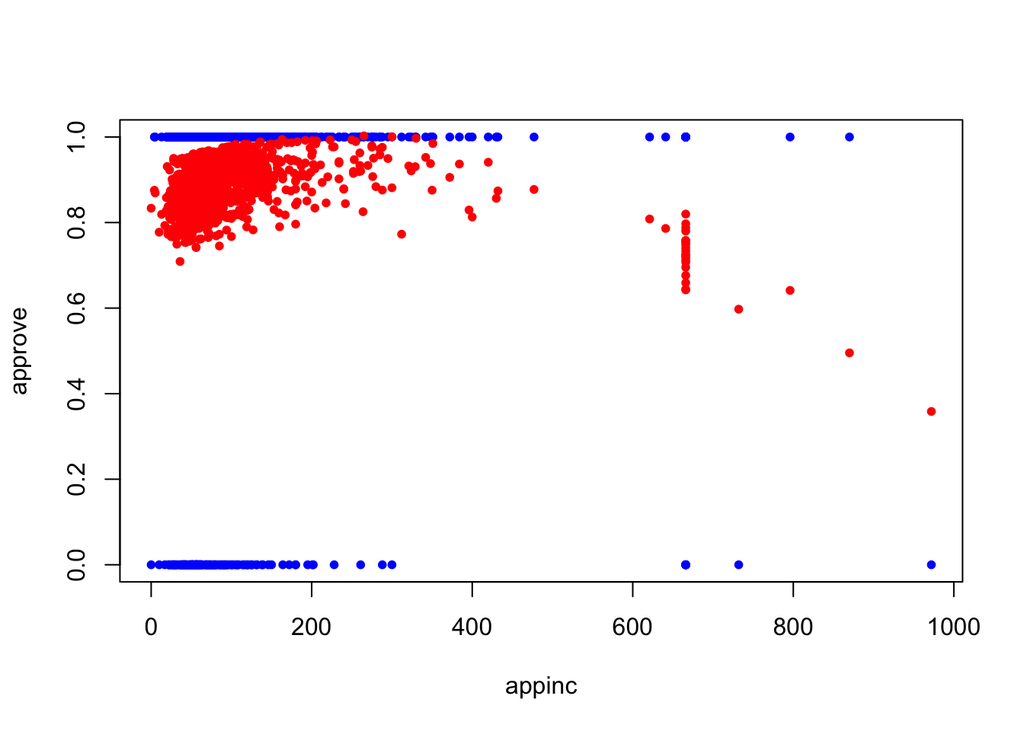

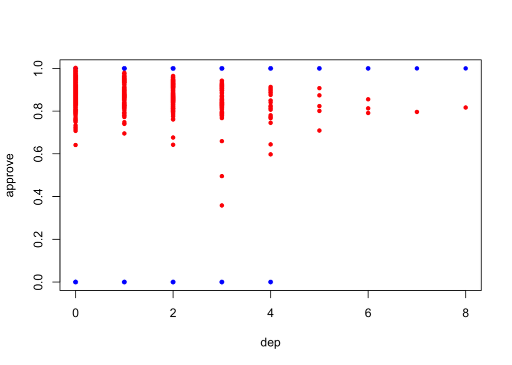

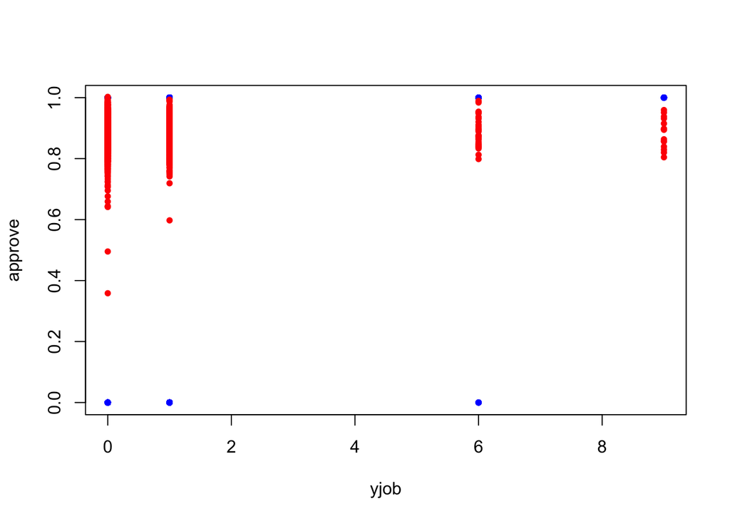

## 6.2 labour force equation

Для датасета `TableF5-1` рассмотрим регрессию **LFP на WA, WA^2, WE, KL6, K618, CIT, UN, log(FAMINC)**

Построим графики фактических наблюдений м прогнозов

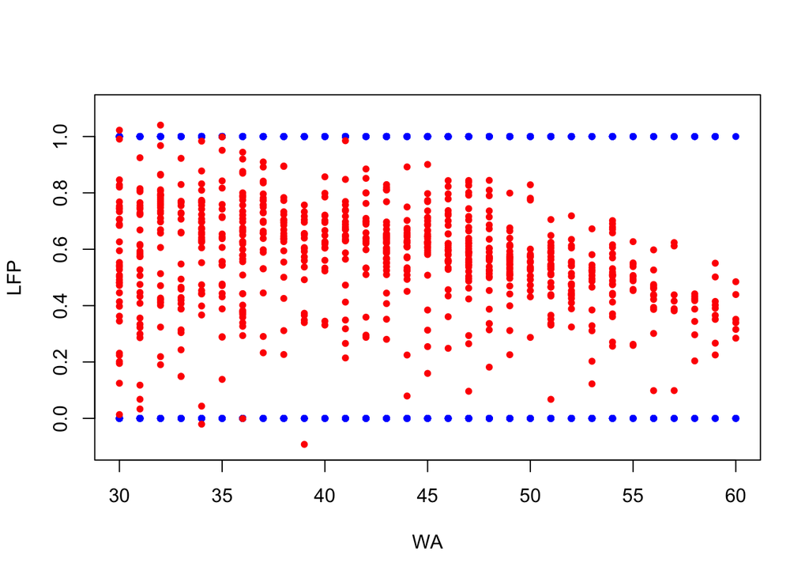

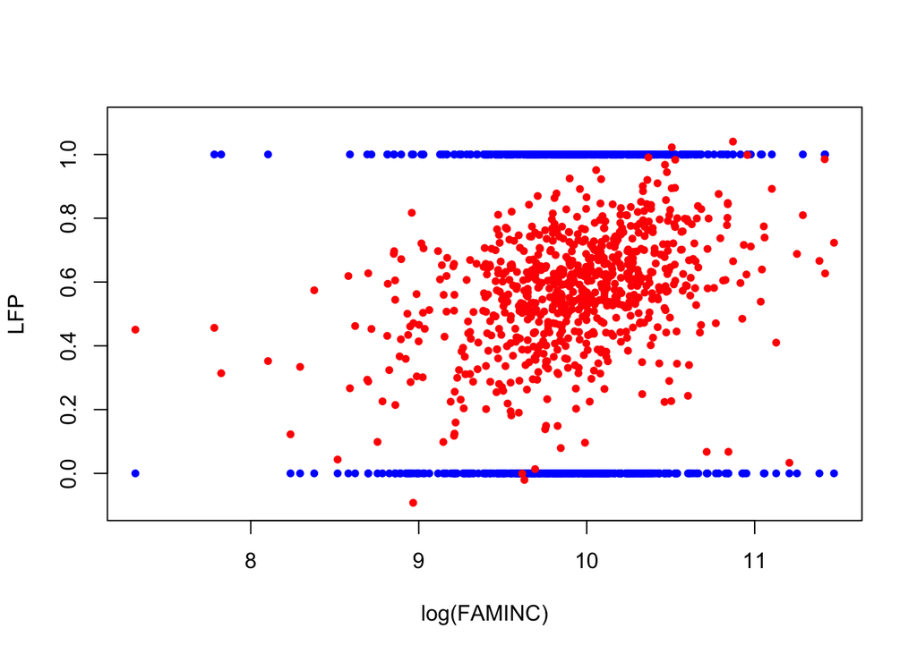

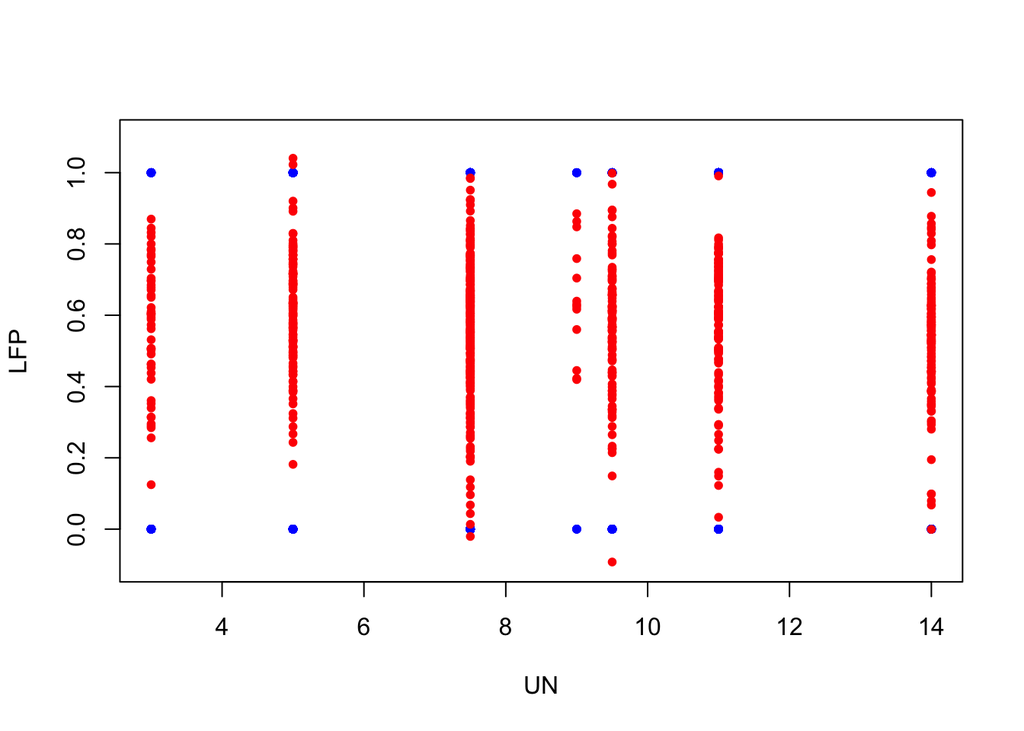